# STA 207: Assignment II

Chenrui_Lu9220509665

**Instructions** You may adapt the code in the course materials or any sources (e.g., the Internet, classmates, friends). In fact, you can craft solutions for almost all questions from the course materials with minor modifications. However, you need to write up your own solutions and acknowledge all sources that you have cited in the Acknowledgement section.

Failing to acknowledge any non-original efforts will be counted as plagiarism. This incidence will be reported to the Student Judicial Affairs.

A consulting firm is investigating the relationship between wages and some demographic factors. The file `Wage.csv` contains three columns, which are

- `wage`, the wage of the subject,
- `ethnicity`, the ethnicity of the subject,
- and `occupation`, the occupation of the subject.

```r
Wage=read.csv('Wage.csv');
library(gplots)
library(lme4)
attach(Wage)
```

1. Write down a two-way ANOVA model for this data. For consistency, choose the letters from $\{Y,\alpha, \beta, \mu, \epsilon\}$ and use the factor-effect form.

   ```r
   table(Wage$ethnicity)
   ```

   ```
   ##
   ##     cauc hispanic    other
   ##      440       27       67
   ```

   ```r
   table(Wage$occupation)
   ```

   ```
   ##
   ## management     office      sales   services  technical     worker
   ##         55         97         38         83        105        156
   ```

   The cell means model for a two-way ANOVA takes the following form,

   $Y_{ijk}=\mu_{ij}+\epsilon_{ijk},k=1,…n,i=1,…,6,j=1,2,3$

   where$\{{\epsilon_{ijk}}\}$ are i.i.d. $N(0,\sigma^2)$ . There are ab unknown means and one unknown $\sigma$ in the cell means model.

   In practice, we often prefer the factor effect form

   $Y_{ijk}=\mu_{..}+\alpha_i+\beta_j+(\alpha\beta)_{ij}+\epsilon_{ijk},k=1,...,n,i=1,...,6,j=1,2,3$

   where$\{\epsilon_{ijk}\}$ are i.i.d. $N(0,\sigma^2)$.

   where ${\alpha_i}$ satisfies that $\sum^6_{i=1}\alpha_i=0$,${\beta_j}$ satisfies that $\sum^3_{j=1}\beta_j=0$ ,$\sum_{i=1}^6(\alpha\beta)_{ij}=\sum_{j=1}^3(\alpha\beta)_{ij}=0$

   And in this model:

   $Y_{ijk}$ is the dependent variable score for the ith level of occupation and the jth level of ethnicity.

   $\mu_{..}$ is mean of the dependent variable-wage.

   $\alpha_i$ is the effect of the ith level of occupation

   $\beta_j$ is the effect of the jth level of the jth of ethnicity

   $(\alpha\beta)_{ij}$ is the interaction effect between occupation and ethnicity at the i th level of occupation and the jth level of ethnicity

   $\epsilon_{ij}$ is the error term, which represents the random variation in the data that is not accounted for by the effects of the independent variables.
2. Obtain the main effects plots and the interaction plot. Summarize your findings.

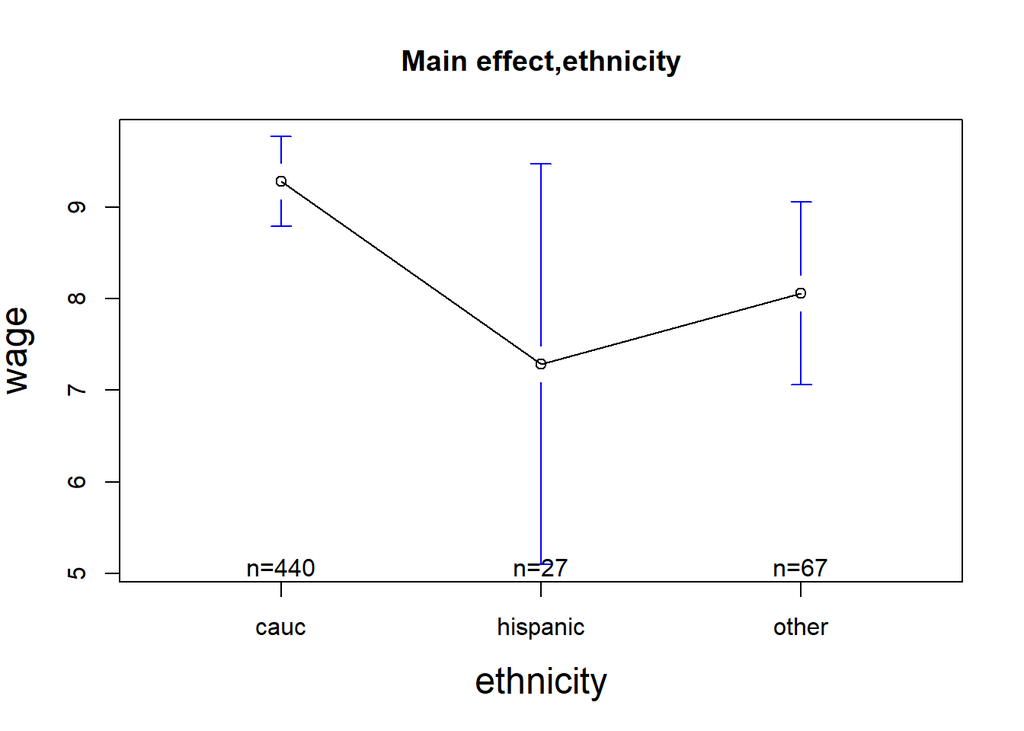

   ```r
   library(gplots)
   Wage$ethnicity=as.factor(Wage$ethnicity)
   Wage$occupation=as.factor(Wage$occupation)
   options(repr.plot.width=12,repr.plot.height=12)
   plotmeans(wage~ethnicity,data=Wage,xlab="ethnicity",ylab="wage",main="Main effect,ethnicity",cex.lab=1.5)
   ```

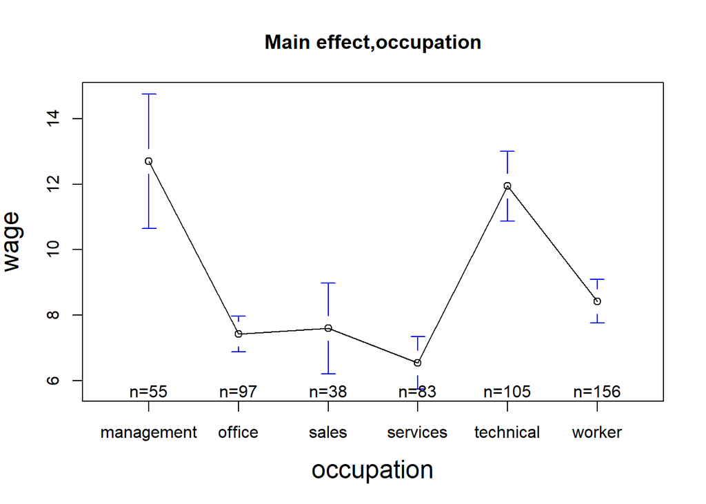

   ```r
   plotmeans(wage~occupation,data=Wage,xlab="occupation",ylab="wage",main="Main effect,occupation",cex.lab=1.5)
   ```

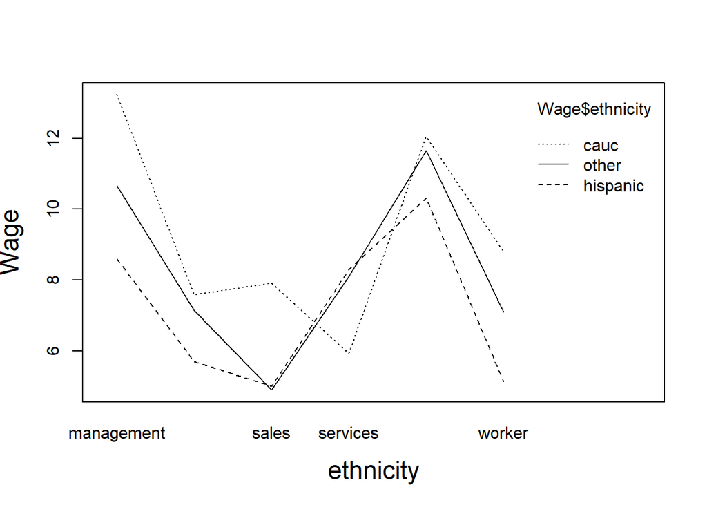

   ```r
   interaction.plot(Wage$occupation,Wage$ethnicity,Wage$wage,cex.lab=1.5,ylab="Wage",xlab="ethnicity")
   ```

   From the plot of ethnicity main effect, we can find that the caucasian have the highest mean wage and the hispanic have the lowest mean wage.

   From the plot of occupation, we can find that there are apparent differences in wages across occupation, and services has the lowest wage.

   From the interaction plot, we can find that technical and management field have higher wages. Besides, apart from the service field, usually for other occupations, caucasian have higher wage.

   ```r
   full_model=lm(wage~occupation+ethnicity+ethnicity*occupation,data=Wage)
   reduced_model=lm(wage~occupation+ethnicity,data=Wage)
   anova(reduced_model,full_model)
   ```

   ```
   ## Analysis of Variance Table
   ##
   ## Model 1: wage ~ occupation + ethnicity
   ## Model 2: wage ~ occupation + ethnicity + ethnicity * occupation
   ##   Res.Df   RSS Df Sum of Sq      F Pr(>F)
   ## 1    526 11446
   ## 2    516 11175 10    270.16 1.2474 0.2579
   ```

   ```r
   library(stats)
   sig.level=0.05
   anova.fit=aov(wage~occupation+ethnicity+ethnicity*occupation,data=Wage)
   summary(anova.fit)
   ```

   ```
   ##                       Df Sum Sq Mean Sq F value Pr(>F)
   ## occupation             5   2538   507.5  23.435 <2e-16 ***
   ## ethnicity              2     94    46.8   2.159  0.116
   ## occupation:ethnicity  10    270    27.0   1.247  0.258
   ## Residuals            516  11175    21.7
   ## ---
   ## Signif. codes:  0 '***' 0.001 '**' 0.01 '*' 0.05 '.' 0.1 ' ' 1
   ```

   ```r
   anova.fit1=aov(wage~occupation+ethnicity,data=Wage)
   summary(anova.fit1)
   ```

   ```
   ##              Df Sum Sq Mean Sq F value Pr(>F)
   ## occupation    5   2538   507.5  23.325 <2e-16 ***
   ## ethnicity     2     94    46.8   2.149  0.118
   ## Residuals   526  11445    21.8
   ## ---
   ## Signif. codes:  0 '***' 0.001 '**' 0.01 '*' 0.05 '.' 0.1 ' ' 1
   ```

   It seems that only ‘occupation’ have significant impact on the response variable. And the interaction and ethnicity do not have significant impact on the response variable, so we can drop the interaction term and ethnicity and use the reduced model.

   Null hypothesis: $H_0: \beta_1=\beta_2=\beta_3=0$

   Alternative hypothesis: $H_1$:not all $\beta_i$ are the zero

   ```r
   summary(anova.fit)
   ```

   ```
   ##                       Df Sum Sq Mean Sq F value Pr(>F)
   ## occupation             5   2538   507.5  23.435 <2e-16 ***
   ## ethnicity              2     94    46.8   2.159  0.116
   ## occupation:ethnicity  10    270    27.0   1.247  0.258
   ## Residuals            516  11175    21.7
   ## ---
   ## Signif. codes:  0 '***' 0.001 '**' 0.01 '*' 0.05 '.' 0.1 ' ' 1
   ```

5. For this part and the next, assume that the occupations have been selected randomly. Write down an appropriate ANOVA model that is additive in the factors and explain the terms in the model.

   and $\alpha_i\sim~_{iid}N(0,\sigma^2_\alpha)$ ,$\beta_j\sim~_{iid}N(0,\sigma^2_\beta)$,$\epsilon_{ijk}\sim~_{iid}N(0,\sigma^2)$

   and all random variables are mutually independent.
6. Assuming that the model in Part 5 is appropriate, obtain an estimate of the proportion of variability that is due to variability in occupation.

```r
aov.fit2=lmer(wage~(1|occupation)+(1|ethnicity),data=Wage)
summary(aov.fit2)
```

```
## Linear mixed model fit by REML ['lmerMod']
## Formula: wage ~ (1 | occupation) + (1 | ethnicity)
##    Data: Wage
##
## REML criterion at convergence: 3178
##
## Scaled residuals:
##     Min      1Q  Median      3Q     Max
## -2.4827 -0.6618 -0.2216  0.4895  6.8410
##
## Random effects:
##  Groups     Name        Variance Std.Dev.
##  occupation (Intercept)  6.2280  2.4956
##  ethnicity  (Intercept)  0.3239  0.5691
##  Residual               21.7670  4.6655
## Number of obs: 534, groups:  occupation, 6; ethnicity, 3
##
## Fixed effects:
##             Estimate Std. Error t value
## (Intercept)    8.781      1.115   7.874
```

From the results show above, we get $\hat{\sigma}^2_\alpha=6.2280$(occupation),$\hat{\sigma}^2_\beta=0.3239$ and $\sigma^2=21.767$. Hence, total variance is 6.2280+0.3239+21.767=28.3189. We see that the latgest contribution to the variance is variability between different occupations which contributes to about 6.228/28.3189=22.00% of the total variance.

7. Consider a two-way ANOVA model with fixed effects $Y_{i,j,k}=\mu + \alpha_i+ \beta_j+\epsilon_{i,j,k}, \ i =1,\ldots, a, j=1,\ldots, b, k=1,\ldots, n$

   where $\{ \alpha_i\}$ satisfies that $\sum_{i}^a \alpha_i=0$, $\{\beta_j\}$ satisfies that $\sum_{j}^b \beta_j=0$, and $\{\epsilon_{i,j,k}\}$ are i.i.d. $N(0,\sigma^2)$. Derive the least squares estimator from the above equation.

   From the equations:

   $G(\mu,\alpha_i,\beta_j)=\sum_i\sum_j\sum_k(Y_{ijk}-\mu-\alpha_i-\beta_j)^2$

   and take the derivation for $\mu,\alpha_i,\beta_j$ $\frac{\partial G}{\partial\mu}=\sum_i\sum_j\sum_k(Y_{ijk}-\mu-\alpha_i-\beta_j)=0$

   $\frac{\partial G}{\partial \alpha_i}=\sum_j\sum_k(Y_{ijk}-\mu-\alpha_i-\beta_j)=0, i=1,...,a$ $\frac{\partial G}{\partial \beta_j}=\sum_i\sum_k(Y_{ijk}-\mu-\alpha_i-\beta_j)=0, j=1,...,b$

   Then, we have

   $Y_{…}-abn\mu-bn\sum\alpha_i-an\sum\beta_j=0$

   $Y_{i..}-bn\mu-bn\alpha_i-n\beta_j=0$

   $Y_{.j.}-an\mu-n\sum\alpha_i-an\sum\beta_j=0$

   And $Y_{…}=\sum_i\sum_j\sum_kY_{ijk}$ ,with constraints: $\sum\alpha_i=0,\sum\beta_j=0$

   So the least squares estimator from the above equation is:

   $\hat\mu=\frac{Y_{…}}{abn}=\bar{Y_{...}}$

   $\hat{\alpha}=\frac{Y_{i..}-\frac{Y_{…}}{a}}{nb}=\bar{Y_{i..}}-\bar{Y_{...}}$

   $\hat{\beta}=\frac{Y_{.j.}-\frac{Y_{…}}{b}}{na}=\bar{Y_{.j.}}-\bar{Y_{...}}$
8. Consider the following models $Y_{i,j,k}=\mu_{i,j}+\epsilon_{i,j,k}, \ k=1,\ldots, n, i =1,\ldots, a, j=1,... b$

   and $Y_{i,j,k}= \sum_{l=1}^a \sum_{m=1}^b \beta_{l,m} X_{l,m;i,j,k}+\epsilon_{i,j,k}, \ k=1,\ldots, n, i =1,\ldots, a, j=1,\ldots, b,$ where $\{\epsilon_{i,j,k}\}$ are i.i.d. $N(0,\sigma^2)$ and $X_{l,m;i,j,k}=1$ when $(l,m)=(i,j)$ and $X_{l,m;i,j,k}=0$ otherwise. Express $\{\beta_{l,m}: l=1,\ldots, a; m=1,\ldots, b\}$ using $\{\mu_{i,j}: i=1,\ldots, a; j=1,\ldots, b\}$.

$\beta_{l,m}$ is the coefficient associated with the indicator variable $X_{l,m;i,j,k}=1$ , which is equal to 1 when $(i,j)$ is the index corresponding to observation $k$ and 0 otherwise. Therefore, from two equations above, we can write that

$\beta_{l,m}=E(\beta_{l,m}) =E(\sum_{l=1}^a \sum_{m=1}^b \beta_{l,m} X_{l,m;i,j,k}) = E(Y_{i,j,k}) = E(\mu_{i,j})=\mu_{i,j}$

since the expected value of $\epsilon_{i,j,k}$ is 0.

In other words, the coefficients $\beta_{l,m}$ in the second model can be expressed as:

$\beta_{l,m} = \mu_{i,j}$

for $l=1,\ldots, a$ and $m=1,\ldots, b$ .

Therefore, the two models represent the same underlying structure, but with different parameters.

9. With some abuse of notation, we rewrite the regression model from Question 8 as $Y= X\beta + \epsilon$ where $Y$ is a $n_T$-dimensional vector, $X$ is an $n_T \times p$ matrix, $\beta$ is a $p$-dimensional vector, and $\{\epsilon\} \sim {\rm MVN}(0, \sigma^2 {\rm I})$, i.e., multivariate normal with covariance matrix $\sigma^2 {\rm I}$. Express the residual sum of squares and explained sum of squares in $Y$ and $X$, and then show that these two sum of squares are independent.

$\hat{\beta}_{OLS}= (X^T X)^{-1} X^T Y$. We then have $\hat{Y}= X (X^T X)^{-1} X^T Y \equiv P_X Y$ and $e = Y-\hat{Y}= Y- X \hat{\beta}= (I- P_X)Y$.

Therefore, we can write down the two sums of squares as
$${\rm SSE}= e^T e= Y^T(I-P_X)Y \ {\rm and} \ {\rm
SSR} = Y^T (P_X-P_1)Y,$$
where $P_1=\mathbf{1}(\mathbf{1}^T\mathbf{1})^{-1} \mathbf{1}^T=\mathbf{1}\mathbf{1}^T/n_T, \mathbf{1}=(1,...,1)^T_{n_T}$.

$P_X, P_1,I-P_X,P_X-P_1$ are orthogonal projectors.

Properties of orthogonal projector: $P_X^T=P_X,P_X^TP_X=P_X, P_X^2=P_X$.

To prove two sum of squares are independent, we need to prove that $cov((I-P_X)Y,(P_X-P_1)Y)=0$.

and the left hand side equals to

$(I_n-P_x)cov(Y,Y)(H-\frac{1}{n}J_n)$

$=(I_n-H)(H-\frac{1}{n}J_n)\sigma^2$

$=(I_n-H)\frac{1}{n}J_n (*)$

And because $HJ_n=J_n$

So $(*)=0$ , which means that $cov(SSE,SSR)=0$

And these two sum of squares are independent.

## Acknowledgement

[Chapter 6 Random and Mixed Effects Models | ANOVA and Mixed Models (ethz.ch)](https://stat.ethz.ch/~meier/teaching/anova/random-and-mixed-effects-models.html#more-than-one-factor)